# Statistical inference with the GSS data

## Setup

### Load packages

```r
library(ggplot2)
library(dplyr)
library(statsr)
```

### Load data

Make sure your data and R Markdown files are in the same directory. When loaded your data file will be called `gss`. Delete this note when before you submit your work.

```r
load("gss.Rdata")
```

## Part 1: Data

The GSS is a personal interview survey and collects information on a wide range of demographic characteristics of respondents and their parents.

The basic GSS design is a repeated cross-sectional survey of a nationally representative sample of non-institutionalized adults who speak either English or Spanish. Subsampling of nonrespondents is done to limit survey costs while maintaining a nationally representative sample.Each GSS formally includes an A sample and a B sample. The preferred interview mode is in person interviews; however, a few interviews will be done by telephone in the event that an inperson contact cannot be scheduled.

Therefore, the random sampling was used in this study. Because of its generalizability, correlation statements can be made by exploring this dataset.

## Part 2: Research question

Research question: Is the university degree related to the income in America citizen between 2008-2012?

Reason: (1) A part of parents consider that the university degree can help children have a higher income career. But another parents do not think so. Therefore, it is interesting to know whether it appear to be a relationship between university degree and income. (2) Because the educations systems of immigrants can be different, so we focus on America citizen only. (3) With the development of technology, occupational composition will change. Instead of exploring the data from 1972 to 2012, we focus on the last five years(2008-2012).

## Part 3: Exploratory data analysis

```r
#see the names of variety
names(gss)
```

```
##   [1] "caseid"   "year"     "age"      "sex"      "race"     "hispanic"
##   [7] "uscitzn"  "educ"     "paeduc"   "maeduc"   "speduc"   "degree"
##  [13] "vetyears" "sei"      "wrkstat"  "wrkslf"   "marital"  "spwrksta"
##  [19] "sibs"     "childs"   "agekdbrn" "incom16"  "born"     "parborn"
##  [25] "granborn" "income06" "coninc"   "region"   "partyid"  "polviews"
##  [31] "relig"    "attend"   "natspac"  "natenvir" "natheal"  "natcity"
##  [37] "natcrime" "natdrug"  "nateduc"  "natrace"  "natarms"  "nataid"
##  [43] "natfare"  "natroad"  "natsoc"   "natmass"  "natpark"  "confinan"
##  [49] "conbus"   "conclerg" "coneduc"  "confed"   "conlabor" "conpress"
##  [55] "conmedic" "contv"    "conjudge" "consci"   "conlegis" "conarmy"
##  [61] "joblose"  "jobfind"  "satjob"   "richwork" "jobinc"   "jobsec"
##  [67] "jobhour"  "jobpromo" "jobmeans" "class"    "rank"     "satfin"
##  [73] "finalter" "finrela"  "unemp"    "govaid"   "getaid"   "union"
##  [79] "getahead" "parsol"   "kidssol"  "abdefect" "abnomore" "abhlth"
##  [85] "abpoor"   "abrape"   "absingle" "abany"    "pillok"   "sexeduc"
##  [91] "divlaw"   "premarsx" "teensex"  "xmarsex"  "homosex"  "suicide1"
##  [97] "suicide2" "suicide3" "suicide4" "fear"     "owngun"   "pistol"
## [103] "shotgun"  "rifle"    "news"     "tvhours"  "racdif1"  "racdif2"
## [109] "racdif3"  "racdif4"  "helppoor" "helpnot"  "helpsick" "helpblk"
```

```r
#selecting my data and giving a numerical summary
educa_income <- gss %>%
  filter(tolower(uscitzn)=="a u.s. citizen") %>%
  filter(between(year,2008,2012)) %>%
  select(incom16,degree,year,uscitzn)
summary(educa_income)
```

```
##                  incom16               degree         year
##  Far Below Average   : 66   Lt High School: 68   Min.   :2008
##  Below Average       : 78   High School   :132   1st Qu.:2008
##  Average             :137   Junior College: 37   Median :2010
##  Above Average       : 53   Bachelor      : 76   Mean   :2010
##  Far Above Average   : 14   Graduate      : 60   3rd Qu.:2012
##  Lived In Institution:  0   NA's          :  2   Max.   :2012
##  NA's                : 27
##                                                                                              uscitzn
##  A U.S. Citizen                                                                                  :375
##  Not A U.S. Citizen                                                                              :  0
##  A U.S. Citizen Born In Puerto Rico, The U.S. Virgin Islands, Or The Northern Marianas Islands   :  0
##  Born Outside Of The United States To Parents Who Were U.S Citizens At That Time (If Volunteered):  0
##
##
##
```

The type of variety “year” should be factor. Since we do not need to use it in analysis, we ignore this problem.

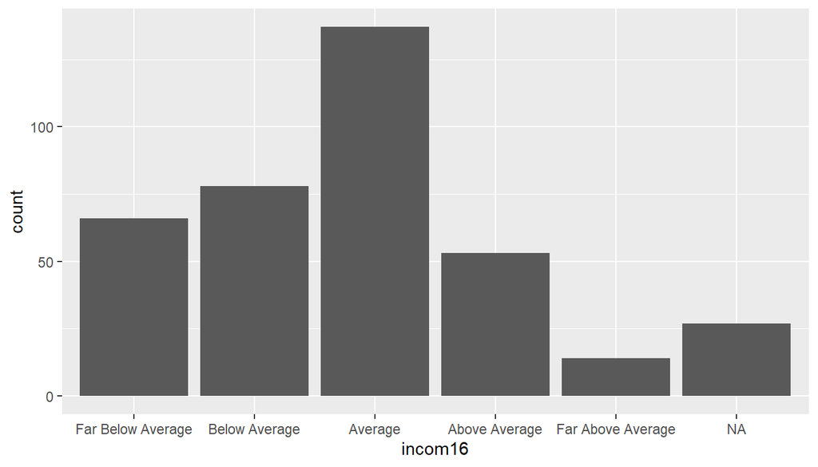

```r
#visualization: the distributions of sample statistics
ggplot(data = educa_income, aes(x=incom16)) + geom_bar()
```

Because the number of “Far Above Average” is too small to meet the condition for the chi-square test, we need to change our research purpose. We only analyse the population who have the income not far away from average.

```r
# We only analyse the population who have the income not far away from average.
educa_income <- educa_income %>%
  filter(incom16 == "Average" |incom16 == "Above Average" | incom16 == "Below Average")
```

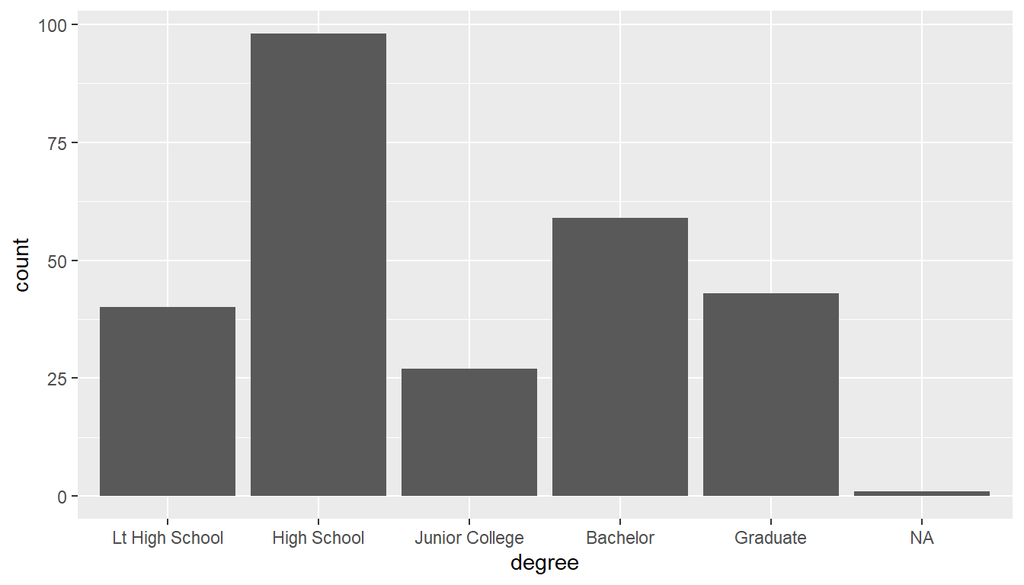

```r
#visualization: the distributions of sample statistics
ggplot(data = educa_income, aes(x=degree)) + geom_bar()
```

We do not need “NA” for our future analysis.

```r
#cleaning our data and separate it into two group: Have university degree(True); Don't have university degree (False)
educa_income <- educa_income %>%
  filter(!is.na(degree)) %>%
  mutate(isUniversity = ifelse(degree == "Bachelor" | degree == "Graduate", "True", "False"))
```

```r
# Looking at the structure of dataframe
str(educa_income)
```

```
## 'data.frame':    267 obs. of  5 variables:
##  $ incom16     : Factor w/ 6 levels "Far Below Average",..: 3 2 3 4 3 2 4 2 3 4 ...
##  $ degree      : Factor w/ 5 levels "Lt High School",..: 5 1 4 3 1 2 4 4 2 2 ...
##  $ year        : int  2008 2008 2008 2008 2008 2008 2008 2008 2008 2008 ...
##  $ uscitzn     : Factor w/ 4 levels "A U.S. Citizen",..: 1 1 1 1 1 1 1 1 1 1 ...
##  $ isUniversity: chr  "True" "False" "True" "False" ...
```

## Part 4: Inference

**state hypotheses** We need to know the relationship between university education and income. We assume: H0 (nothing going on): university education and income are independent. HA (Something going on): university education and income are dependent.

**state method to be used and why and how** (1)All our variable are categorical, so we need to use proportions. (2)The variable “Income” has three levels(>2), so we need to use chi-square test. (3)We have two variables(income and education). so we need to use the chi-square independence test.

We take the income level as the explanatory variable, it divide the data into three groups(“Average”, “Above Average”, “Below Average”). We take the education level as the response variable: Have university degree = success; Don’t have university degree = failure. And then, We are assuming that the rate of response variable dose not vary by explanatory variable. If the P-value < 0.05,we reject H0. if not, we accept the H0.

2: Sample size:

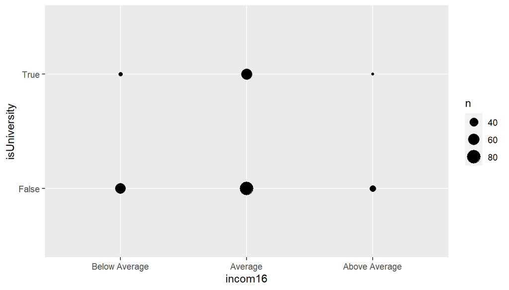

```r
# check conditions: sample size
ggplot(data = educa_income, aes(x=incom16, y= isUniversity)) +geom_count()
```

To meet the condition, each particular scenario(cell) must have at least 5 expected case. We can see the smallest two count are in two groups of the observations who have the university degree.

```r
# check conditions: Whether the smallest two count arre greater than 5.
sample_size <- educa_income %>%
  filter(isUniversity == "True")

sample_size %>%
  group_by(incom16) %>%
  summarise(cell_size =n())
```

```
## # A tibble: 3 x 2
##   incom16       cell_size
##   <fct>             <int>
## 1 Below Average        24
## 2 Average              55
## 3 Above Average        23
```

Because the smallest cell has 23 case(>5), so we can believe every particular cell has more than 5 case.

In summary, our dataset meets the condition for the Chi-Square Independence Test.

**perform inference**

```r
inference(y = isUniversity, x = incom16, data = educa_income, type = "ht", null = 0, statistic = "proportion", success = "True", method = "theoretical", alternative = "greater", sig_level = 0.05, conf_level = 0.95)
```

```
## Response variable: categorical (2 levels)
## Explanatory variable: categorical (6 levels)
## Observed:
##                y
## x               False True
##   Below Average    54   24
##   Average          81   55
##   Above Average    30   23
##
## Expected:
##                y
## x                  False     True
##   Below Average 48.20225 29.79775
##   Average       84.04494 51.95506
##   Above Average 32.75281 20.24719
##
## H0: incom16 and isUniversity are independent
## HA: incom16 and isUniversity are dependent
## chi_sq = 2.7198, df = 2, p_value = 0.2567
```

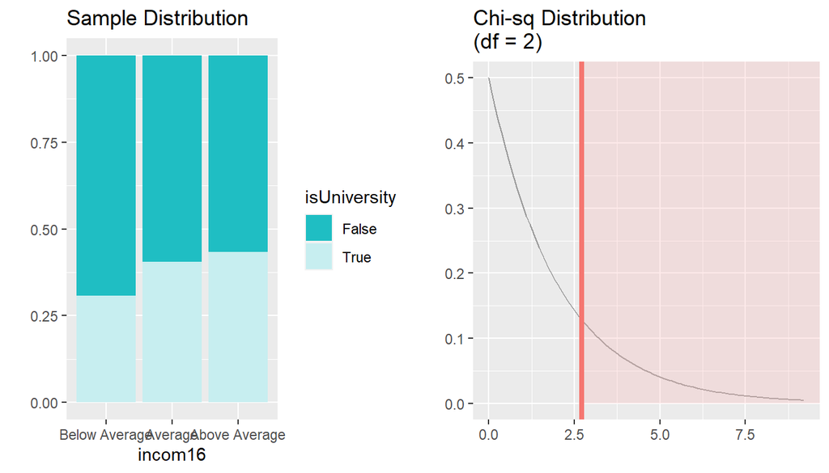